# Exploring the BRFSS data

## Setup

### Load packages

```r
library(ggplot2)
library(dplyr)
```

### Load data

```r
load("brfss2013.RData")
```

## Part 1: Data

#### Description of Data Collected

The Behavioral Risk Factor Surveillance System (BRFSS) is a system of health-related telephone surveys that collect state data about U.S. residents regarding their health-related risk behaviors, chronic health conditions, and use of preventive services.

The BRFSS uses two samples: one for landline telephone respondents and one for cellular telephone respondents. Since landline telephones are often shared among persons living within a residence, household sampling is used in the landline sample.

#### Cell Phone Sampling

The cellular telephone sample is **randomly** generated from a sampling frame of confirmed cellular area code and prefix combinations. Cellular telephone respondents are randomly selected with each having equal probability of selection.

#### Generalizability

Because the phone numbers are is randomly sampled, we can assume independence, and thus we can generalize our conclusions to the greater population.

#### Random Assignment

Because the BRFSS is a survey and not an experiment, no random assignment was used.

## Part 2: Research questions

**Research quesion 1:** What is the relationship between education level and income level? I am interested in the relationship between graduating college and income levels. We are always told that education is the path to higher earning jobs, so I will examine the validity of this claim using the data from the BRFSS study.

**Research quesion 2:** What is the relationship between sex and weight for 18-24 year olds? I am interested in seeing the degree to which our biology (sex), effects our weight in early adulthood.

**Research quesion 3:** What is the association between average height and race for males in California? I chose this topic because height plays a role in overall atheticism, and want to see which races, on average, have the height advantage. I chose to study California because it has a large sample size, and I plan to move there!

## Part 3: Exploratory data analysis

#### Load Libraries And Data

```r
library(dplyr)
library(ggplot2)
load("brfss2013.RData")
d <- brfss2013 # rename data to 'd' for convenience
```

### Research Question 1: What is the relationship between completing college and income level?

For this question I will use two categorical variables `educa` which corresponds to educational attainment, and `income2` which corresponds to the income level. The categories of `educa` range from no education to completing four years of undergraduate level studies. The categories of `income2` range from no income to income greater than $75,000.

#### Remove NA’s for income and education

I removed all observations which did not have records for education attainment and income level.

```r
d <- d[!is.na(d$income2),]
d <- d[!is.na(d$educa),]
```

#### Frequencies of education attainment

Since I am interested in the relationship between education level (specifically whether a person completed college or not) and their income level, I first printed out the relative frequencies of each education level recorded in the survey.

```r
d %>%
  group_by(educa) %>%
  summarise(frequency = n())
```

```
## # A tibble: 6 x 2
##                                                          educa frequency
##                                                         <fctr>     <int>
## 1                   Never attended school or only kindergarten       456
## 2                              Grades 1 through 8 (Elementary)     10256
## 3                        Grades 9 though 11 (Some high school)     22517
## 4                       Grade 12 or GED (High school graduate)    118660
## 5 College 1 year to 3 years (Some college or technical school)    116017
## 6                   College 4 years or more (College graduate)    151915
```

As you can see, the most represented group were people who had completed four years of college, with `151,915` observations. The least represented group were those who did not attend any school (or only kindergarten) with `456` observations.

#### Separate into completed college or not

Since I am interested in the relationship between going to college and income level, I seperated the data into two new dataframes, `didNotCompleteCollege` and `completedCollege`:

```r
completedCollege <- filter(d, educa == "College 4 years or more (College graduate)")
didNotCompleteCollege <- filter(d, educa != "College 4 years or more (College graduate)")
```

```r
count(completedCollege)
```

```
## # A tibble: 1 x 1
##        n
##    <int>
## 1 151915
```

```r
count(didNotCompleteCollege)
```

```
## # A tibble: 1 x 1
##        n
##    <int>
## 1 267906
```

While a greater percentage of the population did not complete college (`267,906` compared to `151,915`), we can still continue the analysis because we still have many observations for both categories.

#### Calculate percentages of income levels of those who completed college and did not complete college

Since we have unequal number of observations for the `didNotCompletCollege` group and `completedCollege` group, we cannot simply compare the frequencies of each income level group, but instead need to focus on percentages. I calculate the relative percentages using the `mutate` function from `dplyr`.

```r
completedCollegeGraph <- completedCollege %>%
  group_by(income2) %>%
  summarise(frequency = n()) %>%
  mutate(percentage = frequency / sum(frequency))
completedCollegeGraph
```

```
## # A tibble: 8 x 3
##             income2 frequency percentage
##              <fctr>     <int>      <dbl>
## 1 Less than $10,000      2873 0.01891189
## 2 Less than $15,000      3037 0.01999144
## 3 Less than $20,000      4455 0.02932561
## 4 Less than $25,000      7165 0.04716453
## 5 Less than $35,000     11191 0.07366619
## 6 Less than $50,000     20249 0.13329164
## 7 Less than $75,000     29145 0.19185071
## 8   $75,000 or more     73800 0.48579798
```

```r
didNotCompleteCollegeGraph <- didNotCompleteCollege %>%
  group_by(income2) %>%
  summarise(frequency= n()) %>%
  mutate(percentage = frequency / sum(frequency))
didNotCompleteCollegeGraph
```

```
## # A tibble: 8 x 3
##             income2 frequency percentage
##              <fctr>     <int>      <dbl>
## 1 Less than $10,000     22508 0.08401454
## 2 Less than $15,000     23704 0.08847879
## 3 Less than $20,000     30338 0.11324121
## 4 Less than $25,000     34495 0.12875785
## 5 Less than $35,000     37604 0.14036266
## 6 Less than $50,000     41206 0.15380768
## 7 Less than $75,000     36041 0.13452853
## 8   $75,000 or more     42010 0.15680873
```

#### Graph percentages of income levels for those who did not complete college

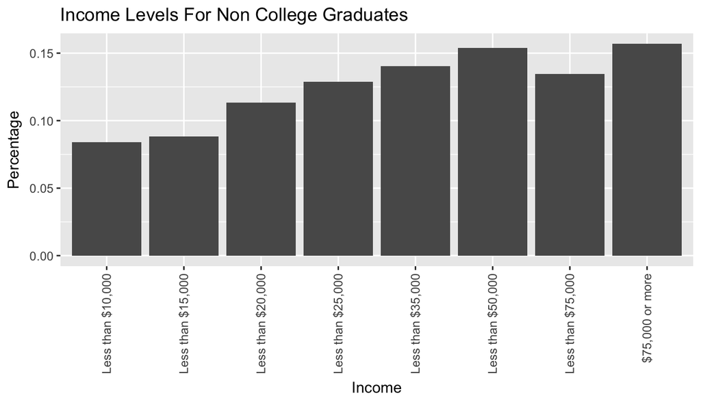

```r
ggplot(didNotCompleteCollegeGraph, aes(x=income2, y = percentage)) +
  geom_bar(stat="identity") +
  theme(axis.text.x=element_text(angle=90,hjust=1,vjust=0.5)) +
  labs(x="Income", y="Percentage") +
  ggtitle("Income Levels For Non College Graduates")
```

The distribution of income levels for those who did not complete college is very loosely uniform, with no one category significantly more represented than the next.

#### Graph percentages of income levels for those who completed college

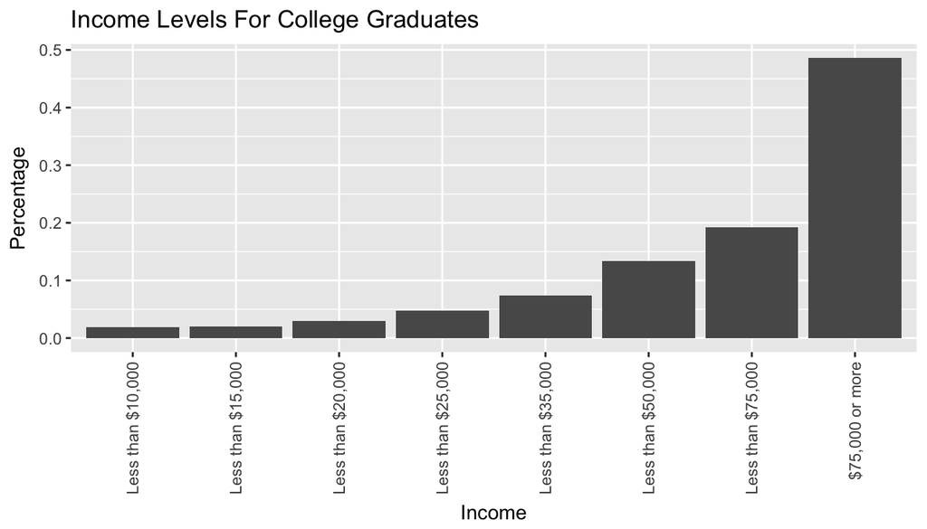

```r
ggplot(completedCollegeGraph, aes(x=income2, y = percentage)) +
  geom_bar(stat="identity") +
  theme(axis.text.x=element_text(angle=90,hjust=1,vjust=0.5)) +
  labs(x="Income", y="Percentage") +
  ggtitle("Income Levels For College Graduates")
```

The distribution for those who completed college is left skewed, with nearly 50% of total observations making over $75,000 a year.

#### Conclusion

It appears as if there is a relationship between completing college and higher incomes. However becasue we do not have detailed information of income levels above $75,000 anually, we cannot determine the precise magnitude of this relationship.

### Research Question 2: What is the relationship between sex and weight for 18-24 year olds?

I am interested in how weight varies for men and women for 18-24 year olds. I chose 18-24 since they are generally healthier, and their would better reflect the true differences between the sexes. I used three variables for my analysis, `wtkg3`, `sex`, and `X_age_g` (age).

#### Clean Dataset

I import a fresh copy of the original dataset into `d`, and then remove all observations with NA’s for the variables I am will use for the analysis:

```r
d <- brfss2013
d <- d[!is.na(d$wtkg3),]
d <- d[!is.na(d$sex),]
d <- d[!is.na(d$X_age_g),]
```

Next, I change the type of the `wtkg3` variable from integer to numeric inorder, to make it easier to graph using ggplot. Also, because the variable `wtkg3` has two implied decimal places, I divide by 100 to get the true value of their weight in kilograms. Since I am used to understand weights in pounds, I create a new variable, `lbs` that reflects weight in pounds, and round to 1 decimal place and use it instead of `wtkg3`:

```r
d$wtkg3 <- as.numeric(d$wtkg3)
d$wtkg3 <- d$wtkg3/100
d$lbs <- d$wtkg3 * 2.20462 # 1 kilogram = 2.20462 pounds
d$lbs <- round(d$lbs, digits = 1)
```

#### Narrow analysis to 18-24 year olds

Since I am interested in how weights differ between the sexes only for 18-24 years, I subset the data to include only 18-24 year olds:

```r
d <- filter(d, X_age_g == "Age 18 to 24")
```

#### Graph overall distribution of weights for 18-24

I want to get an overall picture of the distribution of weights for all 18-24 year olds, so I use a histogram:

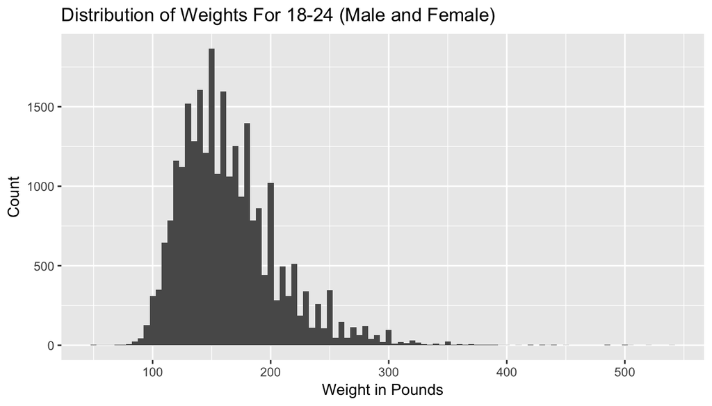

```r
ggplot(d, aes(x=lbs)) +
  geom_histogram(binwidth = 5) +
  labs(x = "Weight in Pounds", y = "Count") +
  ggtitle("Distribution of Weights For 18-24 (Male and Female)")
```

```r
d %>%
  summarise(median = median(lbs), standardDeviation = sd(lbs))
```

```
##   median standardDeviation
## 1    158          42.09531
```

The median weight for 18-24 year olds (males and females) is 158 pounds, with a standard deviation of 42.1 pounds. Since the distribution is right skewed, I choose to use median instead mean as my sample statistic.

#### Analysis of weight statistics for men and women 18-24 years old

Now I’m interested in how the median weights differ between sexes. I construct a box plot that shows the diffrences in the male and female weight distributions and calculate the sample statistics for median, inter-quartile range and standard deviation respectively.

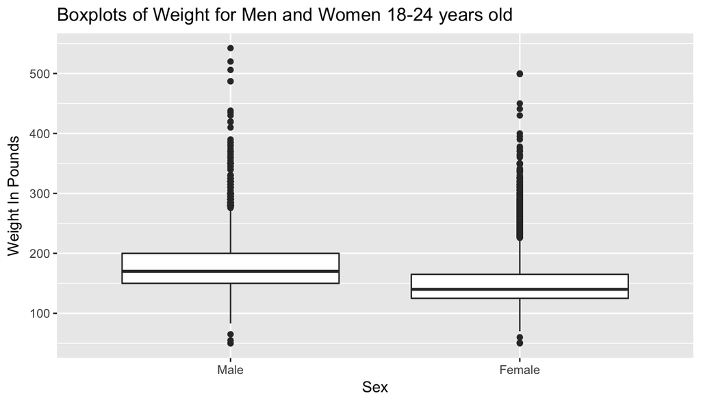

```r
ggplot(d, aes(x=sex, y=lbs)) +
  geom_boxplot() +
  labs(x = "Sex", y = "Weight In Pounds") +
  ggtitle("Boxplots of Weight for Men and Women 18-24 years old")
```

```r
d %>%
  group_by(sex) %>%
  summarise(average = mean(lbs), median = median(lbs), IQR = IQR(lbs), standardDeviation = sd(lbs))
```

```
## # A tibble: 2 x 5
##      sex  average median   IQR standardDeviation
##   <fctr>    <dbl>  <dbl> <dbl>             <dbl>
## 1   Male 179.2154    170    50          40.43493
## 2 Female 149.2340    140    40          38.18255
```

The median weight for males is 170 pounds and females is 140 pounds. The standard deviation for males is 40.4 pounds and 38.2 for females. From the boxplot you can see that both distributions are right skewed, and the interquartile-range for women (40), is narrower than the interquartile-range for men (50).

#### Conclusion

The data suggest that the median weight for males is on average higher and deviates more than the median weight for females among 18-24 year olds.

### Research Question 3: What is the association between average height and race for males in California?

I am interested in the relationship between height and race among men in California. The variables I use in my analysis are `X_imprace`, a categorical variable for race, `htin4` a continous variable for height in inches, and `sex`.

#### Clean Data

Like with the previous two research questions, I import in a fresh copy of the original dataset, `d`. I also clear the dataset of any observations which have NAs coded for both `X_imprace` and `htin4`:

```r
#Relationship between number of sex and race, in California
d <- brfss2013
d <- d[!is.na(d$X_imprace),]
d <- d[!is.na(d$htin4),]
```

Next, I filter the dataset to only include Male observations from California:

```r
d <- filter(d, X_state == "California")
d <- filter(d, sex == "Male")
```

#### Build Plots

Now I am interested in seeing the distribution of all male heights for this state. I construct a histogram:

[figure not shown]

```r
ggplot(d, aes(x=htin4)) +
  geom_bar() +
  labs(y ="Height In Inches", x ="Count") +
  ggtitle("Distribution of Heights For Males in California")
```

#### Analyze By Race

```r
avgHeightByRace <- d %>%
  group_by(X_imprace) %>%
  summarise(meanHeight = mean(htin4), standardDeviation = sd(htin4))
avgHeightByRace$X_imprace <- c("White", "Black", "Asian", "Native American", "Hispanic", "Other") # change labels to fit in plot
avgHeightByRace
```

```
## # A tibble: 6 x 3
##         X_imprace meanHeight standardDeviation
##             <chr>      <dbl>             <dbl>
## 1           White   70.49014          2.929110
## 2           Black   70.47706          3.277057
## 3           Asian   68.12821          2.768529
## 4 Native American   70.05556          2.975562
## 5        Hispanic   67.73248          3.614724
## 6           Other   70.18919          2.524475
```

I construct a barplot to visual show the differences:

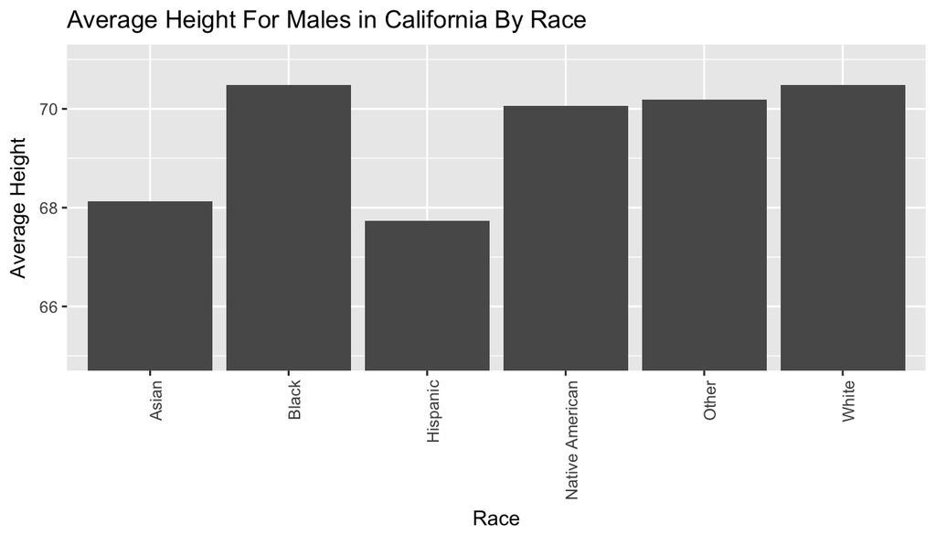

```r
ggplot(avgHeightByRace, aes(x=X_imprace, y= meanHeight)) +
  geom_bar(stat="identity") +
  coord_cartesian(ylim=c(71,65)) +
  theme(axis.text.x = element_text(angle = 90, hjust = 1)) +
  labs(x="Race", y="Average Height") +
  ggtitle("Average Height For Males in California By Race")
```

#### Conclusion

[interactive chart not shown]